# Análise de Dados da RAIS (2012-2016)

**Autor:** Pedro Florencio de Almeida Neto

**Contato:** *pedroflorencio@alu.ufc.br*

### 1. Objetivo

O objetivo desta análise é realizar a coleta, processamento e análise de dados da base disponibilizada pela Relação Anual de Informações Sociais (RAIS) para identificar a desigualdade salarial por raça/cor no mercado de trabalho formal brasileiro, como etapa do processo seletivo de auxiliar de pesquisa para o Instituto de Pesquisa Econômica Aplicada (IPEA).

### 2. Introdução

A desigualdade salarial é uma realidade no Brasil. Ao adicionarmos “raça” como variável, os resultados demonstram ainda mais disparidade, evidenciando resquícios do histórico de exploração colonial dos povos negros. Nesse sentido, o presente estudo visa realizar uma análise quantitativa entre os anos de 2012, 2014 e 2016, acerca da desigualdade racial no mercado de trabalho formal brasileiro. Para isso, a coleta, processamento e análise realizada se deu a partir da base de dados da Relação Anual de Informações Sociais (RAIS/MTE) - importante fonte de informações socioeconômicas sobre a população trabalhadora no país desde 1975, quando instituída.

### 3. Metodologia

A metodologia para abordagem deste estudo é a CRISP-DM (Cross Industry Standard Process for Data Mining). A CRISP-DM é amplamente adotada para conduzir projetos de mineração de dados e ciência de dados. Ela estrutura o processo em seis fases principais: compreensão do negócio, compreensão dos dados, preparação dos dados, modelagem, avaliação e implantação. Essa abordagem iterativa e flexível facilita a adaptação a diferentes domínios e necessidades, garantindo que as análises estejam alinhadas com os objetivos estratégicos da organização. Como o objetivo desta análise alcança o nível de complexidade de análise descritiva (Figura 01), as etapas de modelagem, avaliação e implantação não são implementadas.

Figura 01: Tipos de Análise de Dados

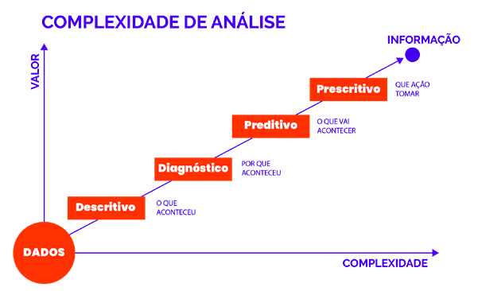

Fonte: A Era dos Dados para o setor público: uma nova cultura organizacional analítica. Íris Lab Gov, 2021.

#### 3.1. Definição dos Dados Utilizados

Os dados utilizados foram obtidos da Relação Anual de Informações Sociais (RAIS), um relatório de informações socioeconômicas solicitado pela Secretaria de Trabalho do Ministério da Fazenda às pessoas jurídicas e outros empregadores anualmente. Por meio de consulta SQL aplicada ao Data Warehouse no Google BigQuery do site Base dos Dados, três tabelas foram geradas. O Data Warehouse do Base dos Dados é composto por duas tabelas no que tangem aos dados da RAIS:

- **Microdados Estabelecimentos:** Cada linha representa um estabelecimento em um ano específico. As colunas mostram detalhes sobre a empresa e seus empregados.
- **Microdados Vínculos:** Cada linha representa um vínculo de trabalho em um ano específico. As colunas mostram informações sobre o vínculo, o empregado e a empresa contratante.

Os materiais de apoio, limitações e inconsistências das tabelas citadas são discutidas nesta [documentação](https://basedosdados.org/dataset/3e7c4d58-96ba-448e-b053-d385a829ef00?tab=userGuide), disponibilizada no site.

#### 3.2. Aquisição de Dados

Para aquisição do dados de forma eficiente e de baixo custo computacional, optou-se pela consulta SQL ao *data warehouse* Google Big Query do site Base dos Dados. O código implementado em R está contido no Quadro 01. Foi removido o ID do projeto do usuário que permite acesso à conta do BigQuery.

Quadro 01: Script de Aquisição dos Dados

```r
library(tidyverse)
library(basedosdados)

set_billing_id("<ID_PROJETO_GBQ>")

# consulta que gera a quantidade vinculos totais e de clt por municipio e ano
query_estabelecimentos <- "
  SELECT
      id_municipio,
      sigla_uf,
      ano,
      SUM(quantidade_vinculos_ativos) AS emprego_total,
      SUM(quantidade_vinculos_clt) AS emprego_vinculo_clt

  FROM `basedosdados.br_me_rais.microdados_estabelecimentos`
  WHERE ano IN (2012, 2014, 2016)
  GROUP BY id_municipio,sigla_uf,ano
  ORDER BY sigla_uf,id_municipio,ano ASC
"

# consulta que gera o salario medio por raca/cor, municipio e ano
query_vinculos <- "
  SELECT id_municipio,
         sigla_uf,
         ano,
         CASE
            WHEN raca_cor IN ('4', '8') THEN 'Negra'
            WHEN raca_cor = '1' THEN 'Indígena'
            WHEN raca_cor = '2' THEN 'Branca'
            WHEN raca_cor = '6' THEN 'Amarela'
            WHEN raca_cor = '9' THEN 'Não identificado'
            WHEN raca_cor = '-1' THEN 'Ignorado'
            ELSE 'Código não encontrado nos dicionários oficiais.'
          END AS raca_cor_nome,
        AVG(valor_remuneracao_media) AS salario_medio

  FROM `basedosdados.br_me_rais.microdados_vinculos`
  WHERE ano in (2012,2014,2016)
  GROUP BY id_municipio, sigla_uf,ano,raca_cor_nome
  ORDER BY sigla_uf,id_municipio,ano,raca_cor_nome ASC
"

query_salario_medio <-
  "SELECT id_municipio,
        sigla_uf,
        ano,
        AVG(valor_remuneracao_media) AS salario_medio

  FROM `basedosdados.br_me_rais.microdados_vinculos`
  WHERE ano in (2012,2014,2016)
  GROUP BY id_municipio, sigla_uf,ano
  ORDER BY sigla_uf,id_municipio,ano ASC"

# lendo a tabela de estabelecimentos do site Base de Dados
df_estabelecimentos <- read_sql(query_estabelecimentos, billing_project_id = get_billing_id())

# salvando df_estabelecimentos em formato csv
write.csv(df_estabelecimentos,"2012_2016_VinculosPorMunicipio.csv", row.names = FALSE)

# lendo a tabela de vinculos do site Base de Dados
df_vinculos <- read_sql(query_vinculos, billing_project_id = get_billing_id())

# salvando df_vinculos em formato csv
write.csv(df_vinculos,"2012_2016_SalarioMedioPorMunicipio.csv", row.names = FALSE)

salario_medio_total <- read_sql(query_salario_medio,
                                billing_project_id = get_billing_id())

write.csv(salario_medio_total,"2012_2016_SalarioMedioTotal.csv", row.names = FALSE)
```

#### 3.3. Entendimento dos Dados

```r
library(dplyr)
library(tidyverse)
# aquisicao dos dados de vinculos, salario medio total e por raca/cor
df_quantidade_vinculos <- read.csv('2012_2016_VinculosPorMunicipio.csv')
df_salario_medio <- read.csv('2012_2016_SalarioMedioPorMunicipio.csv')
df_salario_medio_total <- read.csv("2012_2016_SalarioMedioTotal.csv")
```

```r
head(df_quantidade_vinculos)
```

|  | id_municipio | sigla_uf | ano | emprego_total | emprego_vinculo_clt |
| --- | --- | --- | --- | --- | --- |
| 1 | 1200013 | AC | 2012 | 824 | 808 |
| 2 | 1200013 | AC | 2014 | 909 | 884 |
| 3 | 1200013 | AC | 2016 | 859 | 856 |
| 4 | 1200054 | AC | 2012 | 305 | 286 |
| 5 | 1200054 | AC | 2014 | 342 | 303 |
| 6 | 1200054 | AC | 2016 | 119 | 118 |

```r
head(df_salario_medio)
```

|  | id_municipio | sigla_uf | ano | raca_cor_nome | salario_medio |
| --- | --- | --- | --- | --- | --- |
| 1 | 1200013 | AC | 2012 | Amarela | 664.9900 |
| 2 | 1200013 | AC | 2012 | Branca | 1556.1030 |
| 3 | 1200013 | AC | 2012 | Negra | 985.1164 |
| 4 | 1200013 | AC | 2012 | Não identificado | 1456.6869 |
| 5 | 1200013 | AC | 2014 | Amarela | 1004.0000 |
| 6 | 1200013 | AC | 2014 | Branca | 2030.4880 |

```r
head(df_salario_medio_total)
```

|  | id_municipio | sigla_uf | ano | salario_medio |
| --- | --- | --- | --- | --- |
| 1 | 1200013 | AC | 2012 | 1191.687 |
| 2 | 1200013 | AC | 2014 | 1432.136 |
| 3 | 1200013 | AC | 2016 | 1645.209 |
| 4 | 1200054 | AC | 2012 | 1547.772 |
| 5 | 1200054 | AC | 2014 | 1813.315 |
| 6 | 1200054 | AC | 2016 | 1554.142 |

Neste passo, atentou-se para a correta realização do cálculo de média salarial geral e posteriormente por recorte de raça/cor. No primeiro caso, foi realizado o cálculo antes da agregação por raça/cor e o salvamento desta coluna em formato CSV. Como próximo passo, deseja-se realizar todo o processamento para geração da tabela pedida em linguagem SQL, acelerando o pré-processamento dos dados. As tabelas foram salvas em CSV e disponibilizada no corpo do email para evitar custos de processamento no Google BigQuery.

#### 3.4. Pré-Processamento dos Dados

```r
library(dplyr)
library(tidyverse)

# aquisicao dos dados de vinculos, salario medio total e por raca/cor
df_quantidade_vinculos <- read.csv('2012_2016_VinculosPorMunicipio.csv')
df_salario_medio <- read.csv('2012_2016_SalarioMedioPorMunicipio.csv')
df_salario_medio_total <- read.csv("2012_2016_SalarioMedioTotal.csv")

# pivotando a coluna categorica de raca_cor
df_salario_medio <- df_salario_medio %>%
  pivot_wider(names_from = raca_cor_nome, values_from = salario_medio)

# juntando os dataframes
df_join <- left_join(df_quantidade_vinculos,
                     df_salario_medio,
                     by = c("id_municipio", "ano","sigla_uf"))
df_join <- df_join %>% mutate(id_municipio = as.character(id_municipio))

# adicionando coluna de salario medio sem agregacao por raca/cor
df_salario_medio_total <- df_salario_medio_total %>%
                            mutate(id_municipio = as.character(id_municipio))

df_completo <- left_join(df_join,
                         df_salario_medio_total,
                         by = c("id_municipio", "ano","sigla_uf"))

# adicionando razao entre salario medio de pessoas brancas e negras
df_completo <- df_completo %>% mutate(razao_salario_medio = Branca / Negra)

# selecao das variaveis necessarias
df <- df_completo %>% select('id_municipio',
                             'sigla_uf',
                             'ano',
                             'emprego_total',
                             'emprego_vinculo_clt',
                             'salario_medio',
                             'salario_medio_brancos'='Branca',
                             'salario_medio_negros'='Negra',
                             'razao_salario_medio')

# arredondando os valores numericos
df <- df %>%
  mutate(salario_medio = round(salario_medio, 2),
         salario_medio_brancos = round(salario_medio_brancos, 2),
         salario_medio_negros = round(salario_medio_negros, 2),
         razao_salario_medio = round(razao_salario_medio, 2))

# salvando a tabela em formato CSV
write.csv(df,"2012_2016_DisparidadeSalarial.csv", row.names = FALSE)
```

A etapa de pré-processamento de dados teve como objetivo a realização de junções nas tabelas geradas no BigQuery e cálculo da variável que relaciona o salário médio entre pessoas brancas e negras. Foi necessário o uso do método *pivot_wider()* para transformar em variáveis a coluna que continha a raça/cor dos vínculos formais de emprego.

#### 3.5. Análise Exploratória de Dados (E.D.A.)

Como parte da análise exploratória de dados deste estudo, buscou-se responder a primeira pergunta norteadora. Para uma visualização nítida da distribuição da razão, optou-se pela remoção dos outliers considerando o método do corte por amplitude interquartil, aplicando o produto da amplitude interquartil pelo valor 1,5. A discussão do resultado é apresentada no tópico 4.

##### 3.5.1. Qual a razão entre os salários de brancos e negros no território nacional?

```r
library(dplyr)
library(tidyr)
library(echarts4r)

df <- read.csv("2012_2016_DisparidadeSalarial.csv")

# remocao dos outliers para melhor visualização do histograma
Q1 <- quantile(df$razao_salario_medio, 0.25, na.rm = TRUE)
Q3 <- quantile(df$razao_salario_medio, 0.75, na.rm = TRUE)
IQR <- Q3 - Q1
# limiares
limite_inferior <- Q1 - 1.5 * IQR
limite_superior <- Q3 + 1.5 * IQR
# identificacao de outliers
outliers <- df %>%
  filter(razao_salario_medio < limite_inferior | razao_salario_medio > limite_superior)
# remocao dos outliers
dados_filtrados <- df %>%
  filter(razao_salario_medio >= limite_inferior & razao_salario_medio <= limite_superior)

# producao do histograma da razao salarial
dados_filtrados %>%
  filter(is.finite(razao_salario_medio) & !is.na(razao_salario_medio) & razao_salario_medio >= 0) %>%
  e_charts() %>%
  e_histogram(razao_salario_medio, name = "Quantidade", breaks = 30) %>%
  e_title("Distribuição da Razão Salarial entre Pessoas Brancas e Negras",
          textStyle = list(fontSize = 12)) %>%
  e_x_axis(name = "Razão",
           min=0.5,
           max=1.590,
           interval=.05,
           axisLabel = list(rotate = 45)) %>%
  e_y_axis(name = "Frequência") %>%
  e_theme("walden") %>%
  e_legend(show = FALSE) %>%
  e_tooltip(trigger = "axis")
```

[interactive chart not shown]

```r
df <- df %>% filter(is.finite(razao_salario_medio))
summary(df$razao_salario_medio)
```

```
##    Min. 1st Qu.  Median    Mean 3rd Qu.    Max.
##   0.000   1.020   1.130   1.178   1.250  13.350
```

### 4. Resultados

Como evidenciado pelos dados, a disparidade salarial entre pessoas brancas e negras é uma realidade persistente no Brasil. Aproximadamente 50% das observações da razão salarial média indicam que pessoas brancas recebem pelo menos 13% a mais do que pessoas negras — ou seja, para cada R$1.000,00 recebidos por uma pessoa negra, uma pessoa branca recebe R$1.130,00. Além disso, observa-se que essa desigualdade pode ser ainda mais extrema, com a razão salarial chegando, em casos máximos, a 13 vezes o valor recebido por uma pessoa negra. Por fim, deve-se considerar que a análise foi observada entre os anos de 2012, 2014 e 2016, com base nos vínculos **formais** de emprego.

### 5. Conclusão

O estudo concentrou-se em avaliar a razão entre o salário médio de pessoas brancas e o de pessoas negras nos municípios brasileiros nos anos de 2012, 2014 e 2016. A análise da distribuição dessa razão, por meio de um histograma, evidenciou a existência de desigualdades salariais significativas, que devem ser enfrentadas tanto pelos gestores públicos quanto pela sociedade em geral.

Como próximos passos, recomenda-se obter o histórico da razão salarial nos municípios ao longo do tempo, bem como realizar um recorte por estado. Isso permitirá identificar se a desigualdade está se acentuando ou diminuindo, além de destacar quais estados e municípios apresentam as maiores disparidades — e, por outro lado, quais oferecem bons exemplos para a formulação de políticas públicas. Para isso, a construção de um mapa coroplético pode ser uma ferramenta útil para visualizar e comparar regiões. Além disso, a análise de séries temporais por estado pode oferecer indicativos importantes para a comparação e definição de prioridades entre os entes federativos.

Adicionalmente, observar dados qualitativos sobre onde se concentram as maiores demissões, os motivos dessas demissões (presentes na tabela de vínculos da RAIS) e a quantidade de admitidos por raça e cor pode revelar indícios de uma possível bolha de racismo estrutural no mercado de trabalho brasileiro — especialmente se padrões de exclusão sistemática forem identificados. Essas informações aprofundam o diagnóstico das desigualdades e fortalecem o embasamento para ações públicas mais eficazes.

### 6. Referências Bibliográficas

MONTGOMERY, Douglas C.; RUNGER, George C. *Estatística aplicada e probabilidade para engenheiros*. 6. ed. Rio de Janeiro: LTC, 2016.

WILHER, Vitor. *Utilizando o pacote basedosdados no R*. Análise Macro, 20 maio 2021. Disponível em: https://analisemacro.com.br/data-science/utilizando-o-pacote-basedosdados-no-r/. Acesso em: 2 jun. 2025.

WICKHAM, Hadley; GROLEMUND, Garrett. *R para data science: importação, transformação, visualização e modelagem de dados*. São Paulo: Novatec, 2018.

Governo do Estado do Ceará. *A Era dos Dados para o Setor Público*. Fortaleza, 2021. Disponível em: https://irislab.ce.gov.br/wp-content/uploads/2021/09/LIVRO-DIGITAL-A-Era-dos-Dados-para-o-Setor-P%C3%BAblico.pdf. Acesso em: 3 jun. 2025.